# Orange MFA

First thing, we have to load the FactoMineR library to apply the MFA and the missMDA library to load the dataset.

```r
library(FactoMineR)
library(missMDA)
```

Now, we read the data on which we want to perform the MFA, giving a summary, to have an idea of the data.

```r
data(orange)
head(orange)
```

|  | Color.intensity | Odor.intensity | Attack.intensity | Sweet | Acid | Bitter | Pulp | Typicity |
| --- | --- | --- | --- | --- | --- | --- | --- | --- |
| 1 | 4.791667 | 5.291667 | NA | NA | NA | 2.833333 | NA | 5.208333 |
| 2 | 4.583333 | 6.041667 | 4.416667 | 5.458333 | 4.125000 | 3.541667 | 4.625000 | 4.458333 |
| 3 | 4.708333 | 5.333333 | NA | NA | 4.291667 | 3.166667 | 6.250000 | 5.166667 |
| 4 | 6.583333 | 6.000000 | 7.416667 | 4.166667 | 6.750000 | NA | 1.416667 | 3.416667 |
| 5 | NA | 6.166667 | 5.333333 | 4.083333 | NA | 4.375000 | 3.416667 | 4.416667 |
| 6 | 6.333333 | 5.000000 | 5.375000 | 5.000000 | 5.500000 | 3.625000 | 4.208333 | 4.875000 |

```r
summary(orange)
```

```
 Color.intensity Odor.intensity  Attack.intensity     Sweet            Acid           Bitter           Pulp          Typicity
 Min.   :4.083   Min.   :4.292   Min.   :3.917    Min.   :4.083   Min.   :4.125   Min.   :2.833   Min.   :1.292   Min.   :3.417
 1st Qu.:4.448   1st Qu.:4.958   1st Qu.:4.833    1st Qu.:4.510   1st Qu.:4.375   1st Qu.:3.104   1st Qu.:1.510   1st Qu.:3.958
 Median :4.646   Median :5.292   Median :5.292    Median :4.938   Median :5.042   Median :3.583   Median :2.479   Median :4.438
 Mean   :5.083   Mean   :5.326   Mean   :5.319    Mean   :4.943   Mean   :5.065   Mean   :3.536   Mean   :3.312   Mean   :4.462
 3rd Qu.:5.948   3rd Qu.:5.938   3rd Qu.:5.375    3rd Qu.:5.479   3rd Qu.:5.292   3rd Qu.:3.792   3rd Qu.:4.521   3rd Qu.:5.042
 Max.   :6.583   Max.   :6.167   Max.   :7.417    Max.   :5.792   Max.   :6.750   Max.   :4.375   Max.   :7.333   Max.   :5.250
 NA's   :2       NA's   :1       NA's   :3        NA's   :4       NA's   :3       NA's   :4       NA's   :2
```

```r
nrow(orange)
```

```
[1] 12
```

```r
ncol(orange)
```

```
[1] 8
```

```r
?orange
```

From the description given by the ? command, we have that the Orange data frame is a sensory description of 12 orange juices by 8 attributes.

First thing we need to do is to treat the missing values. Having all quantitative variables, we decide to impute the missing values, replacing them with the mean value of the column to which they belong.

```r
# now we substitute with the mean the NA values in the numerical variables
# first we calculate the mean
cintensity_mean <- mean(orange$Color.intensity, na.rm = TRUE)
ointensity_mean <- mean(orange$Odor.intensity, na.rm = TRUE)
aintensity_mean <- mean(orange$Attack.intensity, na.rm = TRUE)
sweet_mean <- mean(orange$Sweet, na.rm = TRUE)
acid_mean <- mean(orange$Acid, na.rm = TRUE)
bitter_mean <- mean(orange$Bitter, na.rm = TRUE)
pulp_mean <- mean(orange$Pulp, na.rm = TRUE)

# and then we substitute
orange$Color.intensity[is.na(orange$Color.intensity)] <- cintensity_mean
orange$Odor.intensity[is.na(orange$Odor.intensity)] <- ointensity_mean
orange$Attack.intensity[is.na(orange$Attack.intensity)] <- aintensity_mean
orange$Sweet[is.na(orange$Sweet)] <- sweet_mean
orange$Acid[is.na(orange$Acid)] <- acid_mean
orange$Bitter[is.na(orange$Bitter)] <- bitter_mean
orange$Pulp[is.na(orange$Pulp)] <- pulp_mean
```

To see the updated dataset:

```r
summary(orange)
```

```
 Color.intensity Odor.intensity  Attack.intensity     Sweet            Acid           Bitter           Pulp          Typicity
 Min.   :4.083   Min.   :4.292   Min.   :3.917    Min.   :4.083   Min.   :4.125   Min.   :2.833   Min.   :1.292   Min.   :3.417
 1st Qu.:4.510   1st Qu.:4.979   1st Qu.:5.083    1st Qu.:4.812   1st Qu.:4.812   1st Qu.:3.444   1st Qu.:1.531   1st Qu.:3.958
 Median :4.750   Median :5.309   Median :5.319    Median :4.943   Median :5.065   Median :3.536   Median :3.312   Median :4.438
 Mean   :5.083   Mean   :5.326   Mean   :5.319    Mean   :4.943   Mean   :5.065   Mean   :3.536   Mean   :3.312   Mean   :4.462
 3rd Qu.:5.396   3rd Qu.:5.906   3rd Qu.:5.344    3rd Qu.:5.115   3rd Qu.:5.260   3rd Qu.:3.635   3rd Qu.:4.312   3rd Qu.:5.042
 Max.   :6.583   Max.   :6.167   Max.   :7.417    Max.   :5.792   Max.   :6.750   Max.   :4.375   Max.   :7.333   Max.   :5.250
```

Now we don’t have any NA value.

Now that we have treated the missing values in the dataset, it is necessary to choose the group in which we want to divide the columns (variables) of the dataset. Therefore, we divide in two groups of quantitative variables:

- Color.intensity, Odor.intensity, Attack.intensity, Sweet and Acid
- Bitter, Pulp, Typicity

Given that we are performing MFA on the dataset, it is necessary to scale to unit variance each quantitative variable. First, we observe the variance of each column:

```r
for(i in 1:ncol(orange)) {       # for-loop over columns
  print(var(orange[ , i]))
}
```

```
[1] 0.7872475
[1] 0.3613694
[1] 0.7357955
[1] 0.2540838
[1] 0.4621563
[1] 0.1945825
[1] 4.051531
[1] 0.4253341
```

Therefore we proceed in doing so. The MFA() method provided by FactoMine does it for us, specifying the parameter type = ‘s’.

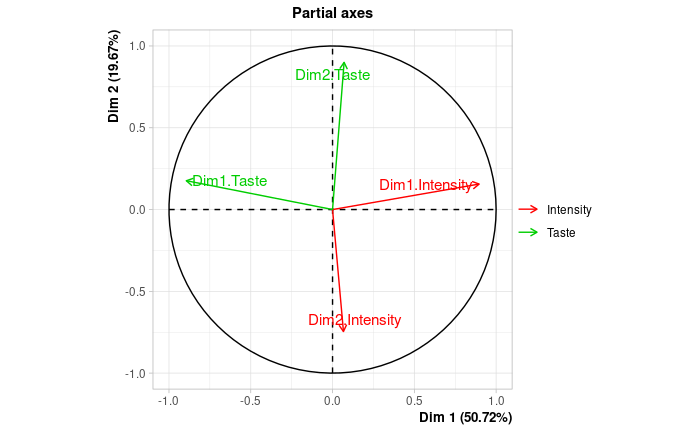

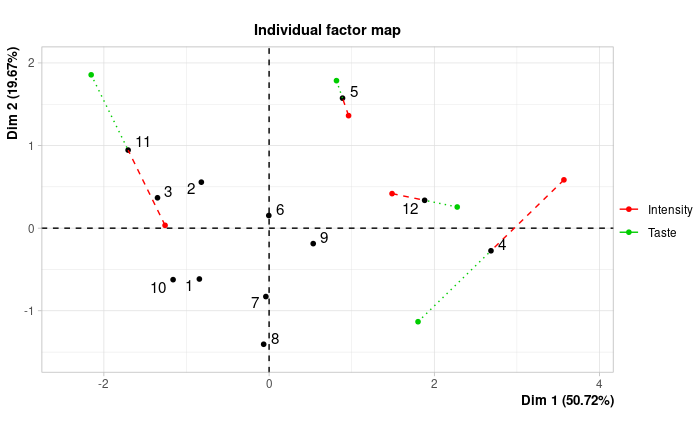

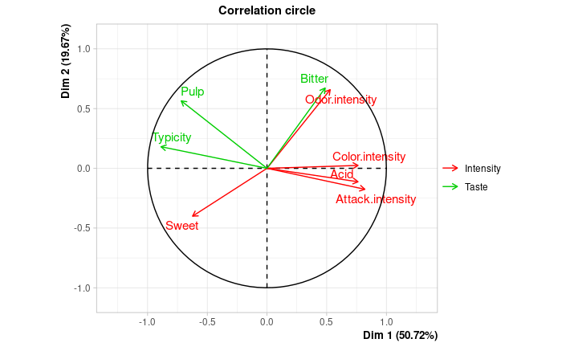

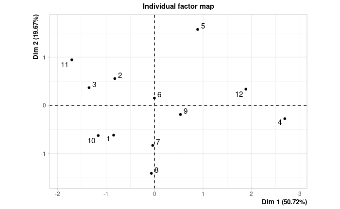

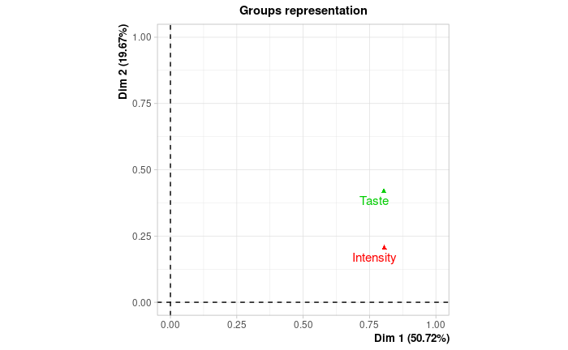

```r
?MFA
res <- MFA(orange, group=c(5,3), type=rep("s", 2),
           name.group=c("Intensity","Taste"))
```

So we applied MFA to the dataset, unit-scaling it. Specifically we decided to divide the quantitative variables in two families:

- The first 5 variables give us the intensity of the orange juice and a description of their acidity and sweetness.
- The last 3 are used to give a description of bitterness, the amount of pulp, and the typicity of each orange juice.

Now it is useful to visualize the main results obtained after applying the MFA.

```r
res
```

```
**Results of the Multiple Factor Analysis (MFA)**
The analysis was performed on 12 individuals, described by 8 variables
*Results are available in the following objects :

  name                 description
1 "$eig"               "eigenvalues"
2 "$separate.analyses" "separate analyses for each group of variables"
3 "$group"             "results for all the groups"
4 "$partial.axes"      "results for the partial axes"
5 "$inertia.ratio"     "inertia ratio"
6 "$ind"               "results for the individuals"
7 "$quanti.var"        "results for the quantitative variables"
8 "$summary.quanti"    "summary for the quantitative variables"
9 "$global.pca"        "results for the global PCA"
```

### Eigenvalues

First we can see the eigenvalues obtained to visualize the proportion of variances retained by the different dimensions (axes).

```r
library(factoextra)
eig.val <- get_eigenvalue(res)
head(eig.val)
```

```
      eigenvalue variance.percent cumulative.variance.percent
Dim.1 1.60944760        50.717546                    50.71755
Dim.2 0.62418163        19.669457                    70.38700
Dim.3 0.39495327        12.445923                    82.83293
Dim.4 0.21068501         6.639189                    89.47212
Dim.5 0.14289380         4.502926                    93.97504
Dim.6 0.08848632         2.788416                    96.76346
```

Visualizing also the screeplot

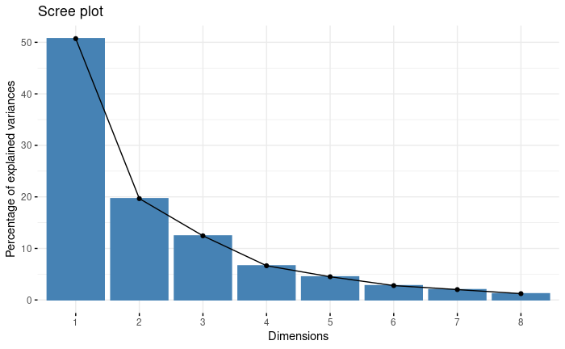

```r
fviz_screeplot(res)
```

```r
res$separate.analyses$Intensity$eig
```

```
       eigenvalue percentage of variance cumulative percentage of variance
comp 1  3.1081581              62.163163                          62.16316
comp 2  0.9749082              19.498163                          81.66133
comp 3  0.4877717               9.755433                          91.41676
comp 4  0.2439585               4.879169                          96.29593
comp 5  0.1852036               3.704071                         100.00000
```

```r
res$separate.analyses$Taste$eig
```

```
       eigenvalue percentage of variance cumulative percentage of variance
comp 1  1.9173190              63.910633                          63.91063
comp 2  0.9083912              30.279708                          94.19034
comp 3  0.1742898               5.809659                         100.00000
```

### Groups

The function get_mfa_var() is used to extract the results for groups of variables. This function returns a list containing the coordinates, the cos2 and the contribution of groups

```r
group <- get_mfa_var(res, "group")
group
```

```
Multiple Factor Analysis results for variable groups
 ===================================================
  Name           Description
1 "$coord"       "Coordinates"
2 "$cos2"        "Cos2, quality of representation"
3 "$contrib"     "Contributions"
4 "$correlation" "Correlation between groups and principal dimensions"
```

Then we can extract each specific component, visualizing it.

```r
# Coordinates of groups
head(group$coord)
```

```
              Dim.1     Dim.2     Dim.3      Dim.4      Dim.5
Intensity 0.8055284 0.2052058 0.1852111 0.15301850 0.12293593
Taste     0.8039192 0.4189758 0.2097422 0.05766652 0.01995787
```

```r
# Cos2: quality of representation on the factore map
head(group$cos2)
```

```
              Dim.1      Dim.2      Dim.3       Dim.4        Dim.5
Intensity 0.5728465 0.03717543 0.03028381 0.020671139 0.0133424074
Taste     0.5242710 0.14239965 0.03568639 0.002697606 0.0003231168
```

```r
# Contributions to the  dimensions
head(group$contrib)
```

```
             Dim.1    Dim.2    Dim.3    Dim.4    Dim.5
Intensity 50.04999 32.87598 46.89443 72.62904 86.03307
Taste     49.95001 67.12402 53.10557 27.37096 13.96693
```

First it is possible to plot the group of variables.

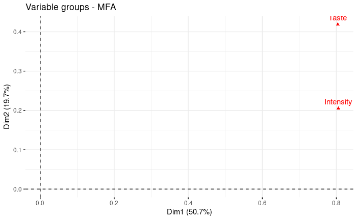

```r
fviz_mfa_var(res, "group")
```

We can observe that the groups give a similar representation of the individuals, in fact, they are close to each other. Specifically, we see that for both, the value on the first dimension is close to 1 (around 0.8) which means that the Lg (Lg(Kj, v1) : projected inertia of all the variables of j-th group on v1) value with the first dimension of the MFA is high for both the groups, so they contribute similarly to the first dimension. For the second dimension we have that the Taste group has a greater value, which means that it contributes more to it.

To draw a bar plot of groups contribution to the dimensions, use the function fviz_contrib():

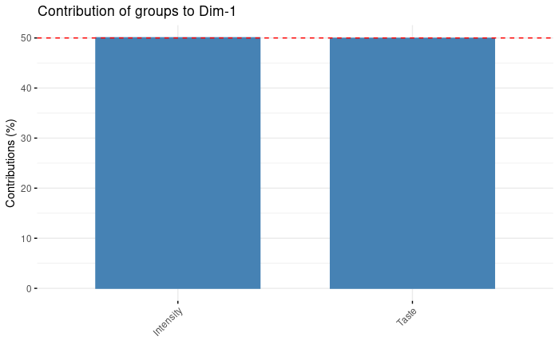

```r
# Contribution to the first dimension
fviz_contrib(res, "group", axes = 1)
```

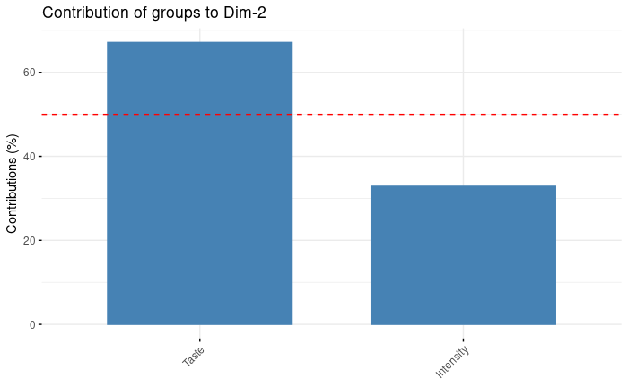

```r
# Contribution to the second dimension
fviz_contrib(res, "group", axes = 2)
```

### Partial Axes

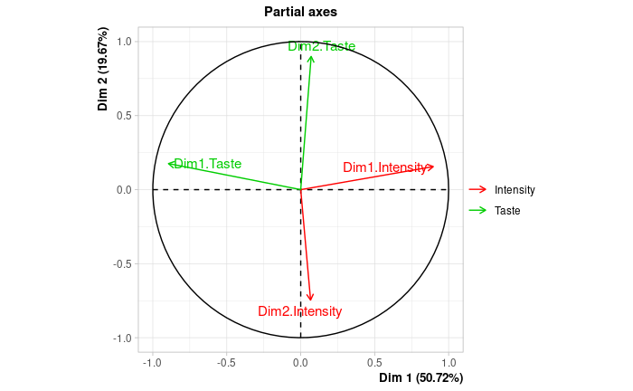

```r
# Graph of the partial axes
plot(res,choix="axes")
```

Partial axes: The graph of partial axes shows the relationship between the principal axes of the MFA and the ones obtained from analyzing each group. From the graph obtained after applying the MFA, we observe that the first dimension of the Intensity group is very much related to the first dimension of the global MFA, while it is pointing in the opposite direction with respect to the second dimension of the global MFA, which means that in this dimension the description provided by such group of variables, diverge from the one of the global MFA. For the Taste group instead, we have that the first dimension, it is pointing in opposite direction with respect to the first dimension of the global MFA, so for this dimension, it has a description which will be different from the one of the global MFA. While it is highly correlated in the second dimension with the global MFA.

```r
res$partial.axes
```

```
$coord
                     Dim.1       Dim.2       Dim.3       Dim.4        Dim.5
Dim1.Intensity  0.89598737  0.15582990  0.41095741  0.04604225  0.012267736
Dim2.Intensity  0.06660939 -0.74557793  0.07799112  0.64144253 -0.093660237
Dim3.Intensity  0.07179645  0.13831474 -0.28562211  0.33654789  0.874384252
Dim4.Intensity  0.08181180 -0.19850185 -0.13647328 -0.21921146  0.004154091
Dim5.Intensity  0.01235046  0.08861914 -0.05063758  0.07055421 -0.028969384
Dim1.Taste     -0.89414922  0.17614324  0.40358158  0.06960414  0.021959125
Dim2.Taste      0.07060771  0.89975122 -0.27946799  0.29668307 -0.125964202
Dim3.Taste     -0.15033069 -0.21995897 -0.32935375  0.34974043 -0.362696866

$cor
                     Dim.1       Dim.2       Dim.3       Dim.4        Dim.5
Dim1.Intensity  0.89598737  0.15582990  0.41095741  0.04604225  0.012267736
Dim2.Intensity  0.06660939 -0.74557793  0.07799112  0.64144253 -0.093660237
Dim3.Intensity  0.07179645  0.13831474 -0.28562211  0.33654789  0.874384252
Dim4.Intensity  0.08181180 -0.19850185 -0.13647328 -0.21921146  0.004154091
Dim5.Intensity  0.01235046  0.08861914 -0.05063758  0.07055421 -0.028969384
Dim1.Taste     -0.89414922  0.17614324  0.40358158  0.06960414  0.021959125
Dim2.Taste      0.07060771  0.89975122 -0.27946799  0.29668307 -0.125964202
Dim3.Taste     -0.15033069 -0.21995897 -0.32935375  0.34974043 -0.362696866

$contrib
                      Dim.1       Dim.2       Dim.3      Dim.4        Dim.5
Dim1.Intensity 4.988006e+01  3.89036747 42.76100684  1.0061887 1.053211e-01
Dim2.Intensity 8.646786e-02 27.93416516  0.48306455 61.2551276 1.925563e+00
Dim3.Intensity 5.026232e-02  0.48099372  3.24154019  8.4367184 8.396625e+01
Dim4.Intensity 3.264133e-02  0.49548546  0.37013686  1.7902168 9.478758e-04
Dim5.Intensity 5.647237e-04  0.07497049  0.03868534  0.1407857 3.499543e-02
Dim1.Taste     4.967561e+01  4.97073899 41.23983880  2.2995164 3.374556e-01
Dim2.Taste     1.467594e-01 61.44866696  9.36908121 19.7938580 5.260893e+00
Dim3.Taste     1.276427e-01  0.70461175  2.49664621  5.2775885 8.368579e+00

$cor.between
                Dim.1.Intensity Dim.2.Intensity Dim.3.Intensity Dim.4.Intensity Dim.5.Intensity   Dim.1.Taste   Dim.2.Taste
Dim.1.Intensity    1.000000e+00   -1.415094e-16   -1.127095e-16   -7.968577e-17   -8.231074e-17 -6.029653e-01  9.944546e-02
Dim.2.Intensity   -1.415094e-16    1.000000e+00    2.515591e-16    8.714782e-17   -1.824357e-16 -1.191161e-01 -4.796366e-01
Dim.3.Intensity   -1.127095e-16    2.515591e-16    1.000000e+00    0.000000e+00    2.683801e-16 -1.085864e-01  1.940685e-01
Dim.4.Intensity   -7.968577e-17    8.714782e-17    0.000000e+00    1.000000e+00   -1.897451e-16 -1.502470e-01 -1.816710e-01
Dim.5.Intensity   -8.231074e-17   -1.824357e-16    2.683801e-16   -1.897451e-16    1.000000e+00 -1.479038e-02  1.165584e-01
Dim.1.Taste       -6.029653e-01   -1.191161e-01   -1.085864e-01   -1.502470e-01   -1.479038e-02  1.000000e+00  3.785638e-16
Dim.2.Taste        9.944546e-02   -4.796366e-01    1.940685e-01   -1.816710e-01    1.165584e-01  3.785638e-16  1.000000e+00
Dim.3.Taste       -2.626828e-01    3.037508e-01   -5.128837e-02    2.206604e-01   -1.476356e-01  1.440417e-16 -1.307914e-17
                  Dim.3.Taste
Dim.1.Intensity -2.626828e-01
Dim.2.Intensity  3.037508e-01
Dim.3.Intensity -5.128837e-02
Dim.4.Intensity  2.206604e-01
Dim.5.Intensity -1.476356e-01
Dim.1.Taste      1.440417e-16
Dim.2.Taste     -1.307914e-17
Dim.3.Taste      1.000000e+00
```

The graphical results is confirmed by the $coord variable obtained in the res$partial.axes. In fact, Dim1.Intensity and Dim1 have a value of 0.89, highlighting that they point in the same direction, while Dim1.Taste and Dim1 have a negative value of -0.89. At the same time Dim2.Intensity and Dim2 have a value of -0.74 while Dim2.Taste and Dim2 are highly correlated, with a value of 0.89.

### Variables

The function get_mfa_var() is used to extract the results for quantitative variables (in our case all the variables). This function returns a list containing the coordinates, the cos2 and the contribution of variables:

```r
var <- get_mfa_var(res, "quanti.var")
var
```

```
Multiple Factor Analysis results for quantitative variables
 ===================================================
  Name       Description
1 "$coord"   "Coordinates"
2 "$cos2"    "Cos2, quality of representation"
3 "$contrib" "Contributions"
```

The different components can be accessed as follow:

```r
# Coordinates
head(var$coord)
```

```
                      Dim.1       Dim.2       Dim.3      Dim.4      Dim.5
Color.intensity   0.7628610  0.02412195  0.32709740  0.4047690  0.2481647
Odor.intensity    0.5292209  0.65828284  0.08323332 -0.3328362  0.3426498
Attack.intensity  0.8196327 -0.17544686  0.29487080  0.2343046  0.1356614
Sweet            -0.6231890 -0.40051474 -0.41979613  0.3669830  0.2800201
Acid              0.7625717 -0.11269596  0.44560892  0.1068298 -0.3260282
Bitter            0.4869191  0.67231449 -0.47068717  0.2548340 -0.1532084
```

```r
# Cos2: quality on the factor map
head(var$cos2)
```

```
                     Dim.1        Dim.2       Dim.3      Dim.4      Dim.5
Color.intensity  0.5819569 0.0005818686 0.106992708 0.16383796 0.06158571
Odor.intensity   0.2800748 0.4333362975 0.006927786 0.11077994 0.11740890
Attack.intensity 0.6717978 0.0307816010 0.086948788 0.05489867 0.01840402
Sweet            0.3883646 0.1604120607 0.176228792 0.13467653 0.07841128
Acid             0.5815156 0.0127003799 0.198567311 0.01141260 0.10629440
Bitter           0.2370902 0.4520067696 0.221546411 0.06494036 0.02347283
```

```r
# Contributions to the dimensions
head(var$contrib)
```

```
                     Dim.1       Dim.2      Dim.3     Dim.4     Dim.5
Color.intensity  11.633514  0.02999237  8.7157620 25.019451 13.866391
Odor.intensity    5.598788 22.33628688  0.5643462 16.917040 26.435317
Attack.intensity 13.429462  1.58663531  7.0829588  8.383494  4.143775
Sweet             7.763538  8.26842761 14.3558213 20.566252 17.654770
Acid             11.624691  0.65464013 16.1755455  1.742801 23.932820
Bitter            7.683203 37.76935622 29.2566524 16.076321  8.567569
```

Now we will describe how to visualize the variables colored by groups. Then it makes sense to highlight variables according to either - their quality of representation on the factor map - their contributions to the dimensions.

Correlation between the variables and dimensions. The R code below plots the variables colored by groups. We use repel = TRUE, to avoid text overlapping.

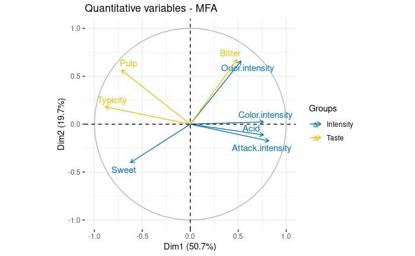

```r
fviz_mfa_var(res, "quanti.var", palette = "jco", repel = TRUE)
```

To make the plot more readable, we can use geom = c(“point”, “text”) instead of geom = c(“arrow”, “text”). We can also change the legend position from “right” to “bottom”, using the argument legend = “bottom”:

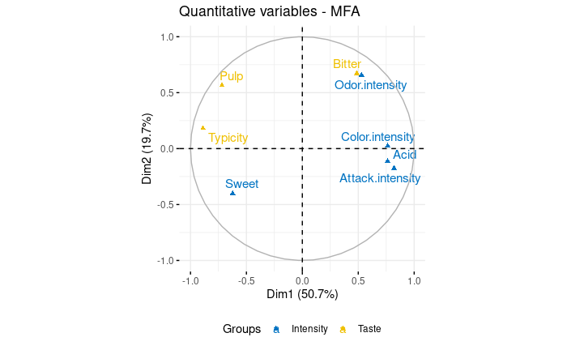

```r
fviz_mfa_var(res, "quanti.var", palette = "jco", repel = TRUE, geom = c("point", "text"), legend = "bottom")
```

The contribution of the variables (in %) to the definition of the dimensions can be visualized using the function fviz_contrib(). Variables are colored by groups.

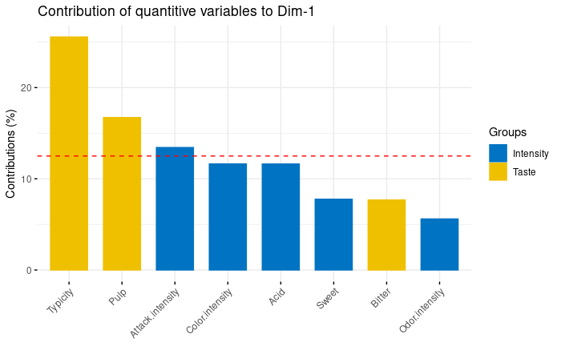

```r
# Contributions to dimension 1
fviz_contrib(res, choice = "quanti.var", axes = 1,
             palette = "jco")
```

Then we can plot the contribution to the second dimension.

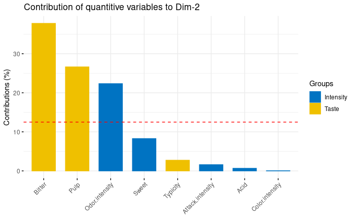

```r
# Contributions to dimension 2
fviz_contrib(res, choice = "quanti.var", axes = 2,
             palette = "jco")
```

The red dashed line on the graph above indicates the expected average value, If the contributions were uniform. The most contributing variables can be highlighted on the scatter plot using the argument col.var = “contrib”. This produces a gradient colors, which can be customized using the argument gradient.cols.

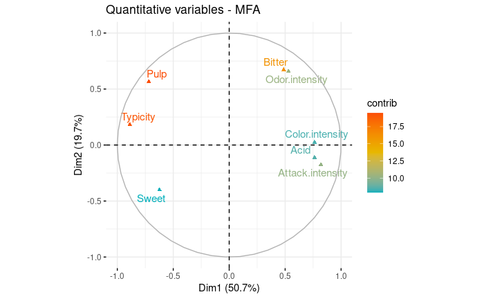

```r
fviz_mfa_var(res, "quanti.var", col.var = "contrib",
             gradient.cols = c("#00AFBB", "#E7B800", "#FC4E07"), repel = TRUE,
             geom = c("point", "text"))
```

Similarly, you can highlight variables using their cos2 values representing the quality of representation on the factor map. If a variable is well represented by two dimensions, the sum of the cos2 is closed to one. For some of the row items, more than 2 dimensions might be required to perfectly represent the data.

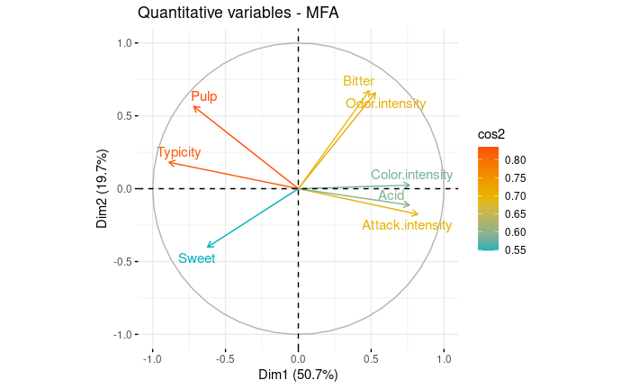

```r
# Color by cos2 values: quality on the factor map
fviz_mfa_var(res, col.var = "cos2",
             gradient.cols = c("#00AFBB", "#E7B800", "#FC4E07"),
             col.var.sup = "violet", repel = TRUE)
```

To create a bar plot of variables cos2:

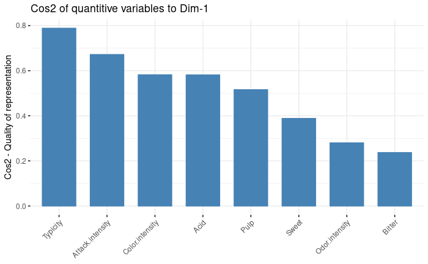

```r
fviz_cos2(res, choice = "quanti.var", axes = 1)
```

### Individuals

Now it is useful to plot the individuals and analyze their relationship with the groups of variables.

```r
ind <- get_mfa_ind(res)
ind
```

```
Multiple Factor Analysis results for individuals
 ===================================================
  Name                      Description
1 "$coord"                  "Coordinates"
2 "$cos2"                   "Cos2, quality of representation"
3 "$contrib"                "Contributions"
4 "$coord.partiel"          "Partial coordinates"
5 "$within.inertia"         "Within inertia"
6 "$within.partial.inertia" "Within partial inertia"
```

To plot individuals, use the function fviz_mfa_ind(). By default, individuals are colored in blue. However, like variables, it’s also possible to color individuals by their cos2 values:

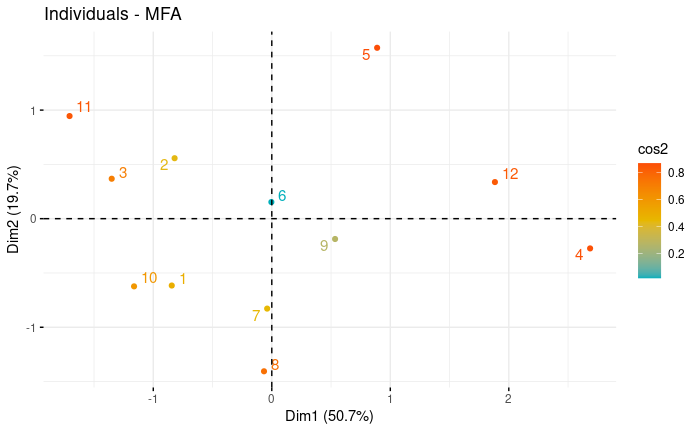

```r
fviz_mfa_ind(res, col.ind = "cos2",
             gradient.cols = c("#00AFBB", "#E7B800", "#FC4E07"),
             repel = TRUE)
```

After having considered the individuals as seen by every group, it may be useful to inspect the graph of the individuals for single groups. The results for individuals obtained from the analysis performed with a single group are named partial individuals. In other words, an individual considered from the point of view of a single group is called partial individual.

In the default fviz_mfa_ind() plot, for a given individual, the point corresponds to the mean individual or the center of gravity of the partial points of the individual. That is, the individual viewed by all groups of variables.

For a given individual, there are as many partial points as groups of variables.

The graph of partial individuals represents each orange juice viewed by each group and its barycenter. To plot the partial points of all individuals:

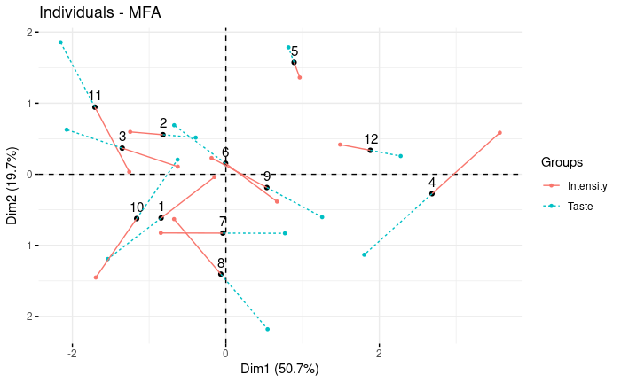

```r
fviz_mfa_ind(res, partial = "all")
```

We can see that orange juice n.4 as described before, has high values of acidity and color intensity, and this characteristics are mostly assigned by the Intensity group of variables, while the Taste group tends to give a description of it less related to such attributes. Another example is for instance orange juice n.11 to which the Taste group assigns high values in the second dimension, describing it as a bitter juice, with a strong odor, while the Intensity group tends to give an opposite opinion with regards to these attributes. For the other points the reasoning proceeds in the same way. Generally, we observe that the descriptions given by the two groups, are not so aligned with the mean description given by the global MFA, in fact the partial points, tend to be distant from the mean points. Moreover, the partial points tend to be often distant from each other, which mean that generally, the two group of variables have different opinions about the attributes to describe the orange juices. The only orange juices in which the partial descriptions made by the two groups of variables are similar to the mean one are the number 2, 5 and 12.

To further inspect the results, we plot the partial axes. The graph of partial axes shows the relationship between the principal axes of the MFA and the ones obtained from analyzing each group using PCA (for groups of continuous variables).

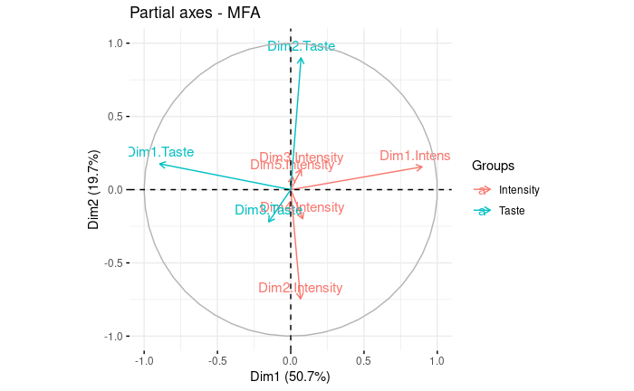

```r
fviz_mfa_axes(res)
```